# Market Shocks Through Time Series Analysis

Understanding COVID-19, Volatility, and Market Risk

Devansh Sachar

2026-05-01

## Market Shocks Through Time Series Analysis

### Main Idea

Financial markets generate data every day.

Time series analysis helps us understand how market behavior changes after major events.

COVID-19 is used as an example of a market shock because it created sudden uncertainty, volatility, and abnormal movements.

## Why Time Series Analysis Matters

Analysts often need to answer:

- Is the market becoming more risky?
- Has behavior changed over time?
- Are unusual events occurring?
- Is the current pattern normal or abnormal?

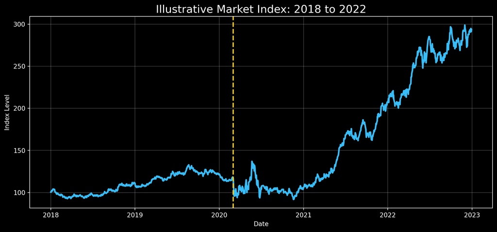

The dashed line marks the beginning of the COVID shock period.

## Core Components of a Time Series

Most time series contain:

- **Trend:** long-term direction
- **Seasonality:** repeated calendar-based pattern
- **Cycles:** broader economic movement
- **Noise:** random short-term variation

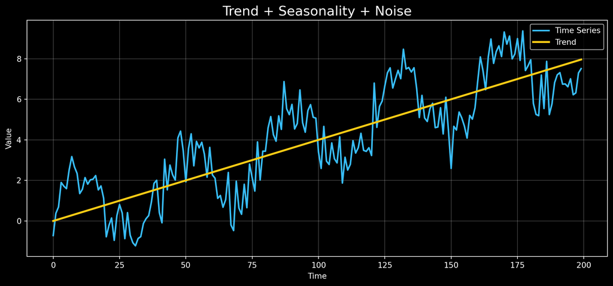

Time series analysis separates meaningful patterns from random fluctuations.

## Prices vs Returns

Prices show the level of the market.

Returns show how much the market moves from one period to the next.

$$R_t = \frac{P_t - P_{t-1}}{P_{t-1}}$$

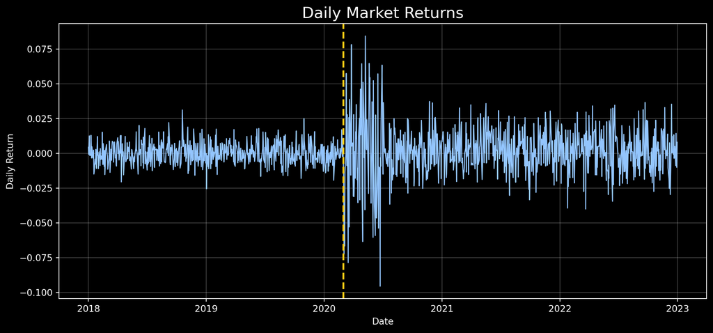

Returns make risk and movement easier to compare over time.

## Volatility: Measuring Market Risk

Volatility measures how much returns fluctuate.

Higher volatility means:

- greater uncertainty
- larger daily movements
- higher risk
- harder forecasting

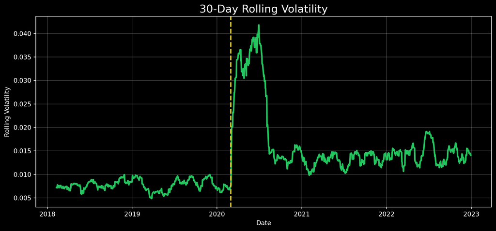

This graph shows market risk increasing sharply during the COVID shock.

## Structural Breaks

A structural break occurs when a time series suddenly changes behavior.

COVID created a break because market conditions shifted quickly.

Before COVID:

- lower volatility
- more stable patterns

During COVID:

- sudden uncertainty
- larger swings
- abnormal returns

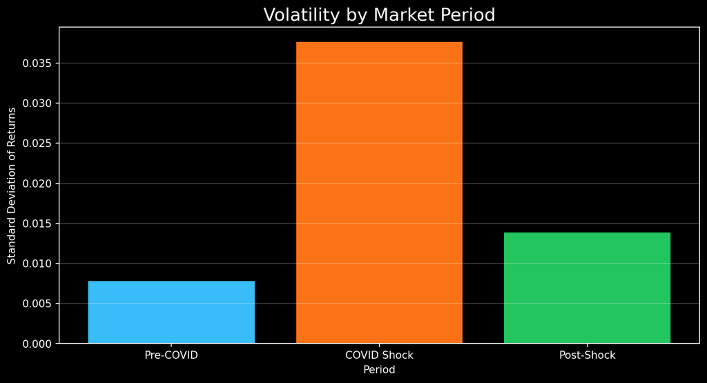

The COVID period has the highest volatility, showing a clear change in market behavior.

## Anomaly Detection

An anomaly is an observation that is very different from normal behavior.

Examples in market data:

- sudden crashes
- panic selling
- unexpected rallies
- large news reactions

Simple rule used here:

Flag returns more than 3 standard deviations away from the average.

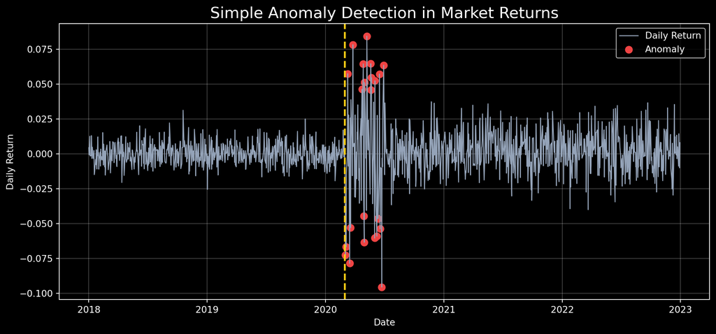

## Key Takeaways

### What We Learned

1. Time series data changes over time.
2. Returns are more useful than raw prices for risk analysis.
3. Volatility measures uncertainty and market risk.
4. Structural breaks show when behavior changes suddenly.
5. Anomaly detection helps identify unusual events.

Time series analysis turns noisy data into clearer business insight.